# PM566 Lab6

Author

Weixi Pan

## Read the data

```r
if (!file.exists("mtsamples.csv")){
  download.file(
    url = "https://raw.githubusercontent.com/USCbiostats/data-science-data/master/00_mtsamples/mtsamples.csv",
    destfile = "mtsamples.csv",
    method   = "libcurl",
    timeout  = 60
  )}

mts <- read.csv("mtsamples.csv")
str(mts)
```

```
'data.frame':   4999 obs. of  6 variables:
 $ X                : int  0 1 2 3 4 5 6 7 8 9 ...
 $ description      : chr  " A 23-year-old white female presents with complaint of allergies." " Consult for laparoscopic gastric bypass." " Consult for laparoscopic gastric bypass." " 2-D M-Mode. Doppler.  " ...
 $ medical_specialty: chr  " Allergy / Immunology" " Bariatrics" " Bariatrics" " Cardiovascular / Pulmonary" ...
 $ sample_name      : chr  " Allergic Rhinitis " " Laparoscopic Gastric Bypass Consult - 2 " " Laparoscopic Gastric Bypass Consult - 1 " " 2-D Echocardiogram - 1 " ...
 $ transcription    : chr  "SUBJECTIVE:,  This 23-year-old white female presents with complaint of allergies.  She used to have allergies w"| __truncated__ "PAST MEDICAL HISTORY:, He has difficulty climbing stairs, difficulty with airline seats, tying shoes, used to p"| __truncated__ "HISTORY OF PRE…
 $ keywords         : chr  "allergy / immunology, allergic rhinitis, allergies, asthma, nasal sprays, rhinitis, nasal, erythematous, allegr"| __truncated__ "bariatrics, laparoscopic gastric bypass, weight loss programs, gastric bypass, atkin's diet, weight watcher's, "| __truncated__ "bariatrics, la…
```

```r
mts <- as_tibble(mts)
```

## Question 1: What specialties do we have?

We can use count() from dplyr to figure out how many different catagories do we have? Are these catagories related? overlapping? evenly distributed?

```r
spec <- mts %>%
  count(medical_specialty)

spec %>%
  arrange(desc(n)) %>%
  knitr::kable()
```

| medical_specialty | n |
| --- | --- |
| Surgery | 1103 |
| Consult - History and Phy. | 516 |
| Cardiovascular / Pulmonary | 372 |
| Orthopedic | 355 |
| Radiology | 273 |
| General Medicine | 259 |
| Gastroenterology | 230 |
| Neurology | 223 |
| SOAP / Chart / Progress Notes | 166 |
| Obstetrics / Gynecology | 160 |
| Urology | 158 |
| Discharge Summary | 108 |
| ENT - Otolaryngology | 98 |
| Neurosurgery | 94 |
| Hematology - Oncology | 90 |
| Ophthalmology | 83 |
| Nephrology | 81 |
| Emergency Room Reports | 75 |
| Pediatrics - Neonatal | 70 |
| Pain Management | 62 |
| Psychiatry / Psychology | 53 |
| Office Notes | 51 |
| Podiatry | 47 |
| Dermatology | 29 |
| Cosmetic / Plastic Surgery | 27 |
| Dentistry | 27 |
| Letters | 23 |
| Physical Medicine - Rehab | 21 |
| Sleep Medicine | 20 |
| Endocrinology | 19 |
| Bariatrics | 18 |
| IME-QME-Work Comp etc. | 16 |
| Chiropractic | 14 |
| Diets and Nutritions | 10 |
| Rheumatology | 10 |
| Speech - Language | 9 |
| Autopsy | 8 |
| Lab Medicine - Pathology | 8 |
| Allergy / Immunology | 7 |
| Hospice - Palliative Care | 6 |

```r
length(unique(mts$medical_specialty))
```

```
[1] 40
```

There are 40 medical specialties.

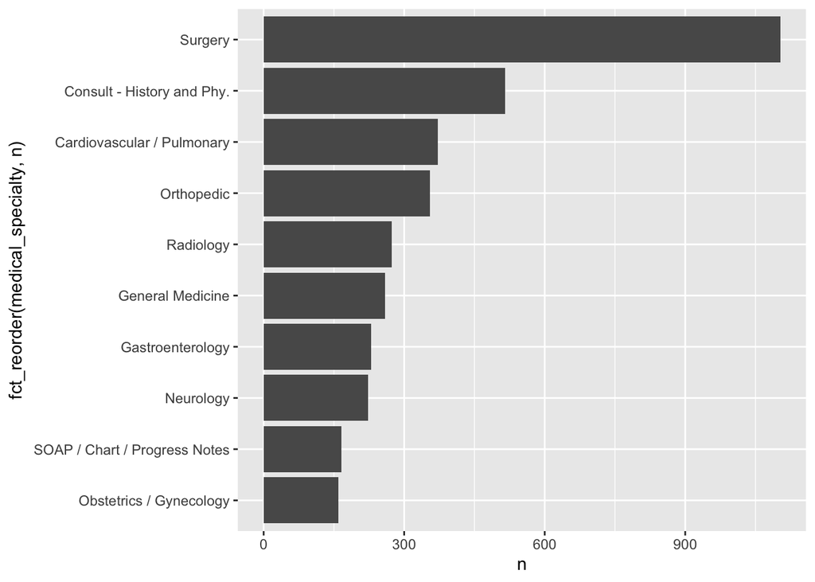

```r
spec %>%
  top_n(10,n)%>%
  ggplot(aes(x=n,y=fct_reorder(medical_specialty,n)))+
  geom_col()
```

## **Question 2**

- Tokenize the the words in the `transcription` column
- Count the number of times each token appears
- Visualize the top 20 most frequent words

Explain what we see from this result. Does it makes sense? What insights (if any) do we get?

```r
mts %>%
  unnest_tokens(token, transcription) %>%
  count(token,sort = TRUE)
```

```
# A tibble: 23,646 × 2
   token        n
   <chr>    <int>
 1 the     149888
 2 and      82779
 3 was      71765
 4 of       59205
 5 to       50632
 6 a        42810
 7 with     35815
 8 in       32807
 9 is       26378
10 patient  22065
# ℹ 23,636 more rows
```

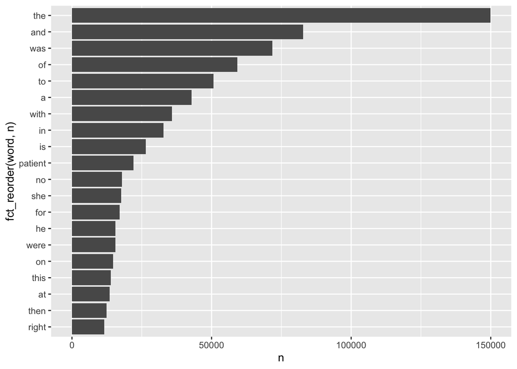

```r
## visualization
mts %>%
  unnest_tokens(word, transcription) %>%
  count(word) %>%
  top_n(20,n) %>%
  ggplot(aes(x=n,y=fct_reorder(word,n)))+
  geom_col()
```

Too much stopwords without meaningful medical words.

## **Question 3**

- Redo visualization but remove stopwords before
- Bonus points if you remove numbers as well

What do we see know that we have removed stop words? Does it give us a better idea of what the text is about?

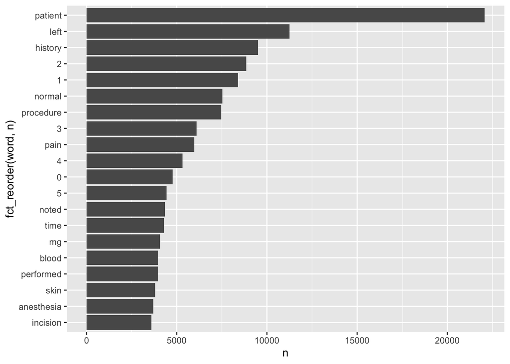

```r
mts %>%
  unnest_tokens(word, transcription) %>%
  anti_join(stop_words, by = "word") %>%
  count(word) %>%
  top_n(20,n) %>%
  ggplot(aes(x=n,y=fct_reorder(word,n)))+
  geom_col()
```

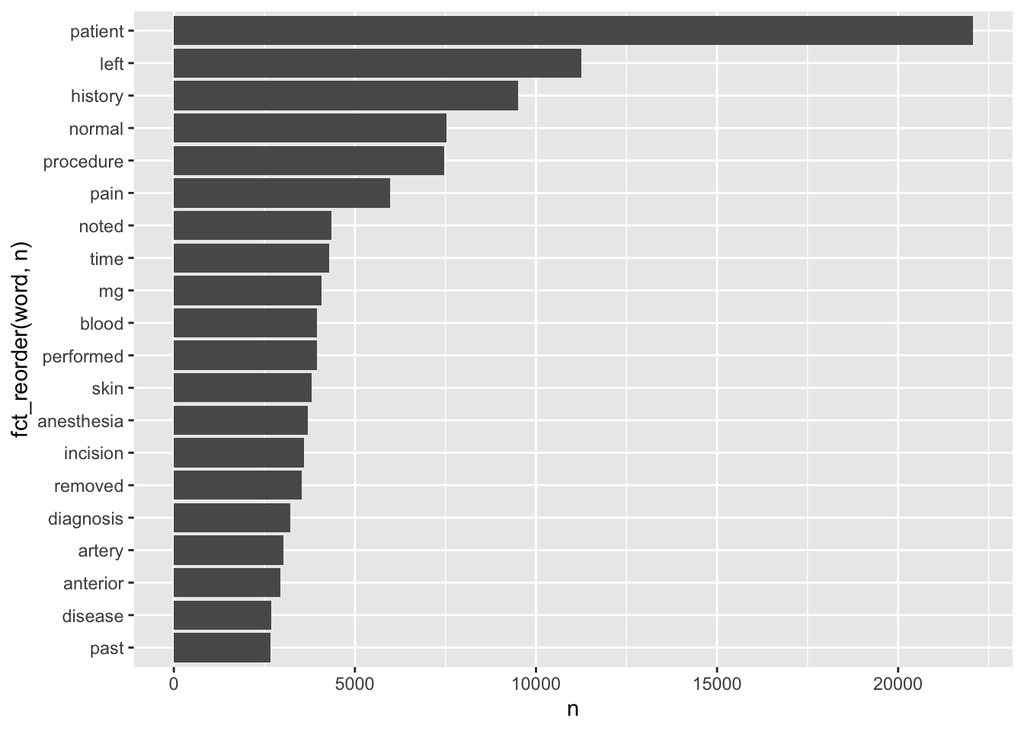

```r
mts %>%
  unnest_tokens(word, transcription) %>%
  anti_join(stop_words, by = "word") %>%

  # use regular expression to filter out numbers
  filter(!grepl(pattern = '^[0-9]+$',x=word))%>%
  count(word) %>%
  top_n(20,n) %>%
  ggplot(aes(x=n,y=fct_reorder(word,n)))+
  geom_col()
```

# Question 4

repeat question 2, but this time tokenize into bi-grams. how does the result change if you look at tri-grams?

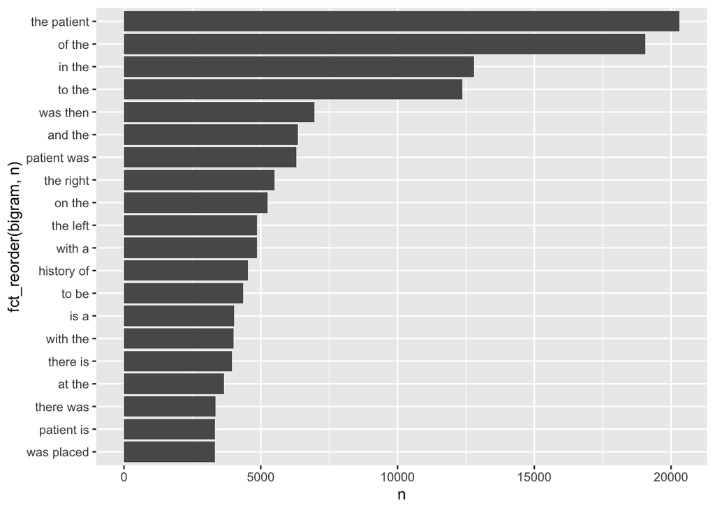

```r
# Bigrams
mts %>%
  unnest_ngrams(bigram, transcription, n = 2) %>%
  count(bigram) %>%
  top_n(20,n) %>%
  ggplot(aes(x=n,y=fct_reorder(bigram,n)))+
  geom_col()
```

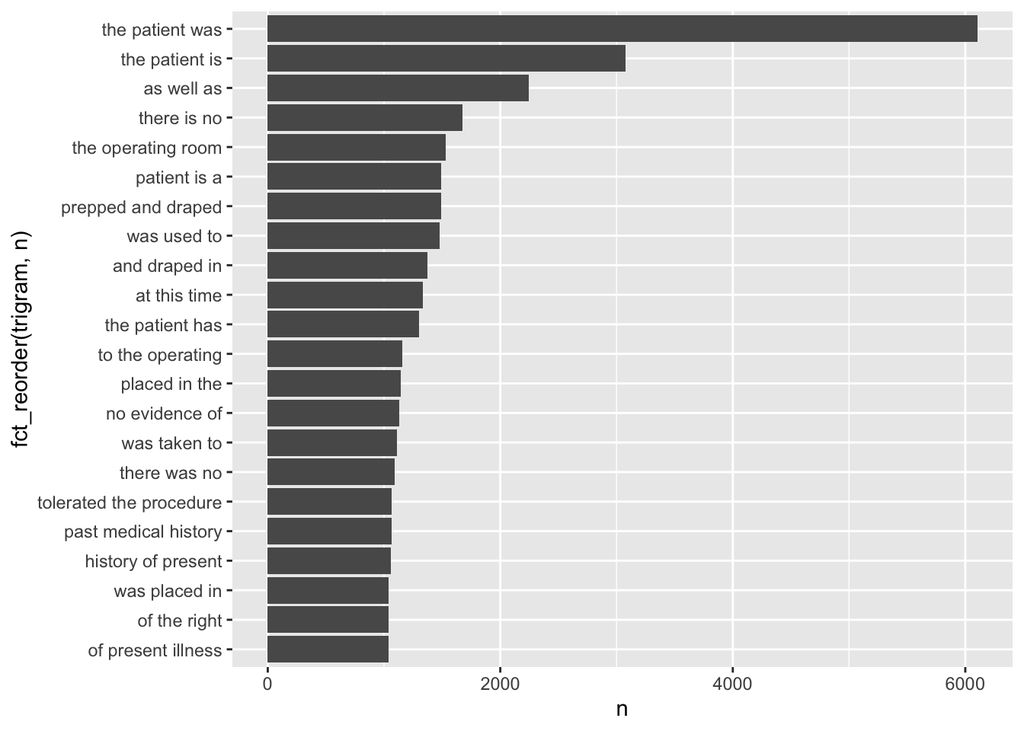

```r
# Trigrams
mts %>%
  unnest_ngrams(trigram, transcription, n = 3) %>%
  count(trigram) %>%
  top_n(20,n) %>%
  ggplot(aes(x=n,y=fct_reorder(trigram,n)))+
  geom_col()
```

Tri-grams seem like having more medical text than bi-grams.

# **Question 5**

Using the results you got from questions 4. Pick a word and count the words that appears after and before it.

```r
ptbigram <- mts %>%
  unnest_ngrams(bigram, transcription, n = 2) %>%
  separate(bigram, into = c("word1", "word2"), sep = " ") %>%
  select(word1, word2) %>%
  filter(word1=='patient'|word2=='patient')
```

before:

```r
ptbigram %>%
  filter(word2=='patient') %>%
  count(word1, sort = TRUE) %>%
  anti_join(stop_words,by=c('word1'='word'))%>%
  top_n(10) %>%
  knitr::kable()
```

| word1 | n |
| --- | --- |
| history | 101 |
| procedure | 32 |
| female | 26 |
| sample | 23 |
| male | 22 |
| illness | 16 |
| plan | 16 |
| indications | 15 |
| allergies | 14 |
| correct | 11 |
| detail | 11 |

after

```r
ptbigram %>%
  filter(word1=='patient') %>%
  count(word2, sort = TRUE) %>%
  anti_join(stop_words,by=c('word2'='word'))%>%
  top_n(10)%>%
  knitr::kable()
```

| word2 | n |
| --- | --- |
| tolerated | 994 |
| denies | 552 |
| underwent | 180 |
| received | 160 |
| reports | 155 |
| understood | 113 |
| lives | 81 |
| admits | 69 |
| appears | 68 |
| including | 67 |

# Question 6

Which words are most used in each of the specialties. you can use group_by() and top_n() from dplyr to have the calculations be done within each specialty. Remember to remove stopwords. How about the most 5 used words?

```r
mts %>%
  unnest_tokens(word, transcription) %>%
  group_by(medical_specialty)%>%
  count(word,sort=TRUE) %>%

  # use regular expression to filter out numbers
  filter(!(word %in% stop_words$word) & !grepl(pattern = '^[0-9]+$',x=word))%>%
  top_n(5,n) %>%
  arrange(medical_specialty,desc(n)) %>%
  knitr::kable()
```

| medical_specialty | word | n |
| --- | --- | --- |
| Allergy / Immunology | history | 38 |
| Allergy / Immunology | noted | 23 |
| Allergy / Immunology | patient | 22 |
| Allergy / Immunology | allergies | 21 |
| Allergy / Immunology | nasal | 13 |
| Allergy / Immunology | past | 13 |
| Autopsy | left | 83 |
| Autopsy | inch | 59 |
| Autopsy | neck | 55 |
| Autopsy | anterior | 47 |
| Autopsy | body | 40 |
| Bariatrics | patient | 62 |
| Bariatrics | history | 50 |
| Bariatrics | weight | 36 |
| Bariatrics | surgery | 34 |
| Bariatrics | gastric | 30 |
| Cardiovascular / Pulmonary | left | 1550 |
| Cardiovascular / Pulmonary | patient | 1516 |
| Cardiovascular / Pulmonary | artery | 1085 |
| Cardiovascular / Pulmonary | coronary | 681 |
| Cardiovascular / Pulmonary | history | 654 |
| Chiropractic | pain | 187 |
| Chiropractic | patient | 85 |
| Chiropractic | dr | 66 |
| Chiropractic | history | 56 |
| Chiropractic | left | 54 |
| Consult - History and Phy. | patient | 3046 |
| Consult - History and Phy. | history | 2820 |
| Consult - History and Phy. | normal | 1368 |
| Consult - History and Phy. | pain | 1153 |

[output cut: 180 more lines]

# **Question 7 - extra**

Find your own insight in the data:

Ideas:

- Interesting ngrams
- See if certain words are used more in some specialties then others

```r
mts %>%
  unnest_tokens(word, transcription) %>%
  count(word,medical_specialty, sort = TRUE)%>%
   filter(!(word %in% stop_words$word) & !grepl(pattern = '^[0-9]+$',x=word))%>%
   bind_tf_idf(word, medical_specialty, n) %>%
  arrange(desc(tf_idf))
```

```
# A tibble: 143,923 × 6
   word         medical_specialty               n      tf   idf tf_idf
   <chr>        <chr>                       <int>   <dbl> <dbl>  <dbl>
 1 carbohydrate " Diets and Nutritions"        37 0.0209  2.30  0.0482
 2 calories     " Diets and Nutritions"        24 0.0136  1.61  0.0218
 3 meal         " Diets and Nutritions"        26 0.0147  1.29  0.0190
 4 reactivity   " Lab Medicine - Pathology"     7 0.00603 3.00  0.0181
 5 snack        " Diets and Nutritions"        15 0.00848 2.08  0.0176
 6 tooth        " Dentistry"                  108 0.0160  1.05  0.0167
 7 linguistic   " Speech - Language"           13 0.00691 2.30  0.0159
 8 servings     " Diets and Nutritions"        13 0.00735 2.08  0.0153
 9 tumor        " Lab Medicine - Pathology"    35 0.0302  0.470 0.0142
10 muir         " Speech - Language"           10 0.00532 2.59  0.0138
# ℹ 143,913 more rows
```